# main_updated

**Major League Baseball Win-Rate Predictions**

Spring 2025 Data Science Project

Zaeem Ali, Charles Burometto, Neel Kumar, Siddharth Singh

*Contributions*

zaeem

- A, C, F; one method plus figure for exploratory data analysis, analyzed relationship between salary and win rate using chi2 test, created a visualization for results

charles

- A, B, D, E, F, G; came up with topic idea of baseball statistics, prepared and preprocessed the data, created model for runs scored/allowed vs win rate and salary vs runs scored/allowed, worked on model for determining the most important offensive stats, visualized R^2 score for polynomial degrees, wrote analysis of those steps.

neel

- C, F, H; one method plus figure for exploratory data analysis, analyzed relationship between ERA and win percentage using two-sample t-test and created visualization, wrote introduction, helped analyze and gather insight from the overall results, wrote conclusion

siddharth

- C, D, E, F; one method plus figure for exploratory data analysis, helped figure out relationships between salary versus runs scored and salary versus runs allowed, helped drop features from the random forest regressor and tested the new model plus visual, added links to helpful information in conclusion.

**Introduction**

What is your topic? What question(s) are you trying to answer with your analysis? Why is answering those questions important?

We wanted to figure out the most important factors in MLB are the most important to winning. In sports in general but especially baseball, predictive models are growing in importance when teams evaluate talent. We specifically wanted to look at which statistics are the most important to a team's winning percentage and the effect salary has on it.

This question is extremely important to different baseball teams because every team has a set amount of money that they have to spend to create the best basbeall team possible. They have to find out the most efficient way to spend money and whether it is more effective on offense or defense and what players would help them the most. In a world where player salaries are extremely high, it's imperative that teams get the best value for their money.

**Data Curation**

```python
# Imports
import pandas as pd
import numpy as np
import matplotlib.pyplot as plt

# Constants
RANDOM_STATE=42
```

*Kaggle - Aggregating by Team*

Batting Data:

Collecting common batting statistics for each team. 'AVG' stands for batting average, the rate that a team is able to get hits. 'OBP' stands for on base percentage, the rate that a team is able to get on base, through hits, walks, or other means. 'SLG' stands for slugging, a batting average weighted by the number of bases reached each hit, rewarding more powerful hits. 'OPS' stands for on base plus slugging, the sum of on base percentage and slugging, which gives a well-rounded metric of offensive success.

```python
# Batting data
team_batting = pd.read_csv('Kaggle/Batting.csv')[['teamID', 'yearID', 'AB', 'H', '2B', '3B', 'HR', 'BB', 'SO', 'IBB', 'HBP', 'SH', 'SF']].dropna().groupby(['teamID', 'yearID']).sum()
team_batting['PA'] = team_batting['AB'] + team_batting['BB'] + team_batting['SF'] + team_batting['SH'] + team_batting['HBP']
team_batting['AVG'] = team_batting['H'] / team_batting['AB']
team_batting['OBP'] = (team_batting['BB'] + team_batting['HBP'] + team_batting['H']) / team_batting['PA']
team_batting['SLG'] = (team_batting['H'] + team_batting['2B'] + 2 * team_batting['3B'] + 3 * team_batting['HR']) / team_batting['AB']
team_batting['OPS'] = team_batting['OBP'] + team_batting['SLG']
```

Pitching Data:

Collecting the 'ERA' statistic for each team. 'ERA' stands for earned run average and measures the average number of runs allowed by pitchers per game, not counting any defensive errors.

```python
# Pitching Data - just ERA
team_pitching = pd.read_csv('Kaggle/Pitching.csv')[['teamID', 'yearID', 'ER', 'IPouts']].dropna().groupby(['teamID', 'yearID']).sum()
team_pitching['ERA'] = 27 * team_pitching['ER'] / team_pitching['IPouts']
```

Salary Data:

Computing the ratio of a team's salary to the league's average salary that year. Handles inflation by measuring how much a team is spending relative to the rest of the league that year.

```python
# Salary Data
team_salaries = pd.read_csv('Kaggle/Salaries.csv')[['teamID', 'yearID', 'salary']].dropna().groupby(['teamID', 'yearID']).sum()
year_salaries = team_salaries.groupby('yearID').mean()
team_salaries = team_salaries.join(year_salaries, on='yearID', rsuffix='_league_avg')
team_salaries['salary/avg_salary'] = team_salaries['salary'] / team_salaries['salary_league_avg'] # comparing team salary to average team salary that year
```

Aggregation:

Combines tables together to get all relevant stats for each team every year.

```python
# General Team Data
teams = pd.read_csv('Kaggle/Teams.csv')[['yearID', 'teamID', 'name', 'attendance', 'G', 'W', 'L', 'R', 'RA']].dropna()
teams = teams.groupby(['teamID', 'yearID']).sum() # Sum isn't necesary with one piece of data, but it gets table into samed group format as others
teams['W%'] = teams['W'] / teams['G'] # Win rate

# Joining tables together
aggregate_teams = team_batting.join(team_pitching).join(team_salaries).join(teams)
aggregate_teams['avg_runs_scored'] = aggregate_teams['R'] / aggregate_teams['G']
aggregate_teams['avg_runs_allowed'] = aggregate_teams['RA'] / aggregate_teams['G']
aggregate_teams = aggregate_teams[['name', 'AVG', 'OBP', 'SLG', 'OPS', 'avg_runs_scored', 'ERA', 'avg_runs_allowed', 'salary', 'salary/avg_salary', 'G', 'W%']].dropna()
aggregate_teams
```

| teamID | yearID | name | AVG | OBP | SLG | OPS | avg_runs_scored | ERA | avg_runs_allowed | salary | salary/avg_salary | G | W% |
| --- | --- | --- | --- | --- | --- | --- | --- | --- | --- | --- | --- | --- | --- |
| ANA | 1997 | Anaheim Angels | 0.272033 | 0.343354 | 0.416311 | 0.759665 | 5.117284 | 4.516499 | 4.901235 | 31135472.0 | 0.773356 | 162 | 0.518519 |
|  | 1998 | Anaheim Angels | 0.271758 | 0.332590 | 0.415453 | 0.748043 | 4.858025 | 4.487535 | 4.833333 | 41281000.0 | 0.968823 | 162 | 0.524691 |
|  | 1999 | Anaheim Angels | 0.255552 | 0.319361 | 0.394976 | 0.714337 | 4.388889 | 4.791337 | 5.098765 | 55388166.0 | 1.112042 | 162 | 0.432099 |
|  | 2000 | Anaheim Angels | 0.279673 | 0.349757 | 0.472459 | 0.822216 | 5.333333 | 5.015884 | 5.364198 | 51464167.0 | 0.926651 | 162 | 0.506173 |
|  | 2001 | Anaheim Angels | 0.260674 | 0.324385 | 0.404972 | 0.729357 | 4.265432 | 4.200556 | 4.506173 | 47535167.0 | 0.727333 | 162 | 0.462963 |
| ... | ... | ... | ... | ... | ... | ... | ... | ... | ... | ... | ... | ... | ... |
| WAS | 2011 | Washington Nationals | 0.242419 | 0.304433 | 0.382650 | 0.687084 | 3.875776 | 3.583027 | 3.993789 | 63856928.0 | 0.687989 | 161 | 0.496894 |
|  | 2012 | Washington Nationals | 0.261443 | 0.319563 | 0.427605 | 0.747167 | 4.512346 | 3.340522 | 3.666667 | 80855143.0 | 0.827095 | 162 | 0.604938 |
|  | 2013 | Washington Nationals | 0.251104 | 0.309079 | 0.397535 | 0.706614 | 4.049383 | 3.585889 | 3.864198 | 113703270.0 | 1.124096 | 162 | 0.530864 |
|  | 2014 | Washington Nationals | 0.253158 | 0.317889 | 0.392999 | 0.710888 | 4.234568 | 3.029238 | 3.425926 | 131983680.0 | 1.240325 | 162 | 0.592593 |
|  | 2015 | Washington Nationals | 0.251105 | 0.318130 | 0.402542 | 0.720672 | 4.339506 | 3.619656 | 3.919753 | 155587472.0 | 1.328240 | 162 | 0.512346 |

888 rows × 12 columns

**Exploratory Data Analysis**

*Salary and Year Correlation Below*

Measuring correlation between salary and year.

```
             years  salaries
years     1.000000  0.349737
salaries  0.349737  1.000000
```

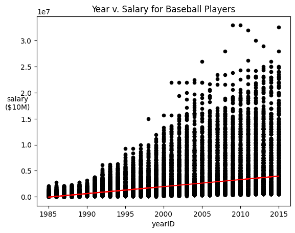

```python
#ss39
#kaggle
kaggle_salaries_df = pd.read_csv('Kaggle/Salaries.csv')

#year v. salaries (in 10s of millions of $)
kaggle_salaries_df=kaggle_salaries_df.sort_values(by=['salary'], ascending=True).reset_index()
years_v_sal={'years':kaggle_salaries_df['yearID'],'salaries':kaggle_salaries_df['salary']}
years_v_sal_df = pd.DataFrame(years_v_sal)

#plot
a=kaggle_salaries_df.plot.scatter(x='yearID', y='salary', c='Black').set_ylabel("salary\n($10M)", rotation=360)
yvs_c,yvs_m = np.polyfit(kaggle_salaries_df['yearID'], kaggle_salaries_df['salary'], 1)
plt.plot(kaggle_salaries_df['yearID'], yvs_c*kaggle_salaries_df['yearID'] + yvs_m, color='red')
plt.title("Year v. Salary for Baseball Players")

#correlation of year and salary (slightly positive)
print(years_v_sal_df.corr())
```

*Correlation Analysis*

The correlation between salary and year is positive 0.349737, indicating that as the year increases, so do the salaries. The scatterplot between year and salary shows the trend of increasing salaries, especially in the upper end, while the lower end of salaries only increases gradually.

*ERA vs Win Percentage Hypothesis Test Below*

H0: There is no difference between the mean win percentage of teams with below-average (Earned Run Average) ERA and teams with above-average ERA.

HA: There is a difference between the mean win percentage of teams with below-average ERA and teams with above-average ERA.

We will use $\alpha = 0.05$.

```python
from scipy.stats import ttest_ind

#Getting average ERA
avg = aggregate_teams['ERA'].mean()

#Separating teams into above average ERA and below average ERA
below_avg = aggregate_teams[aggregate_teams['ERA'] < avg]
above_avg = aggregate_teams[aggregate_teams['ERA'] > avg]

#Performing a two sample t-test
statistic, pvalue = ttest_ind(below_avg['W%'], above_avg['W%'])
print(f"T-statistic: {statistic:.3f}")
print(f"P-value: {pvalue:.3f}")
```

```
T-statistic: 15.474
P-value: 0.000
```

*Hypothesis Test Analysis*

Based on our hypothesis test and our p-value $0.000 < \alpha$, we would reject the null hypothesis. Our test shows that there is a significant difference between the win percentages of teams with above average ERA and below average ERA.

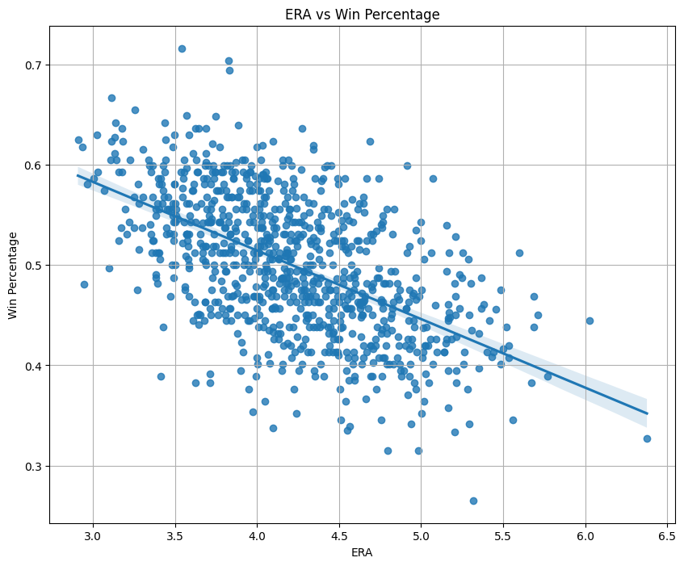

```python
#Creating a scatterplot to show ERA vs Win Percentage
import seaborn as sns
plt.figure(figsize=(10, 8))
sns.regplot(data=aggregate_teams, x='ERA', y='W%')

#Labeling title, x-axis, y-axis
plt.grid(True)
plt.title("ERA vs Win Percentage")
plt.xlabel("ERA")
plt.ylabel("Win Percentage")
plt.show()
```

*Scatter Plot Analysis*

The scatter plot shows that there's a negative correlation between Win Percentage and ERA. This supports the idea that teams that have lower ERA (allowing fewer runs) will win more games than teams with higher ERA (allowing more runs).

*Salary vs Win Rate Test Below*

HO = There is no association between team salary tier (categorical version of salary) and win tier (categorical version of W%)

HA = There is some association between team salary tier (categorical version of salary) and win tier (categorical version of W%)

We will use $\alpha = 0.05$.

```python
temp = aggregate_teams.copy() # copying original df

temp['salary_tier'] = pd.qcut(temp['salary/avg_salary'], 3, labels=['Low', 'Medium', 'High']) # creating salary tiers

median_wr = temp['W%'].median()
temp['win_tier'] =  (temp['W%'] > median_wr).map({True: 'High', False: 'Low'}) # High is above median, Low is below median

cont_table = pd.crosstab(temp['salary_tier'], temp['win_tier']) # create contingency table
cont_table
```

| win_tier salary_tier | High | Low |
| --- | --- | --- |
| Low | 89 | 207 |
| Medium | 151 | 145 |
| High | 194 | 102 |

```python
from scipy.stats import chi2_contingency

chi2_stat, p_val, dof, expected = chi2_contingency(cont_table) # chi2 test

print(f"Chi-Square Statistic: {chi2_stat:.4f}")
print(f"p-value: {p_val:.6f}")
```

```
Chi-Square Statistic: 75.3445
p-value: 0.000000
```

*Hypothesis Test Analysis*

The p-value is $0.000000 < \alpha$. Therefore we reject the null hypothesis and say that a team's salary tier affects their win tier.

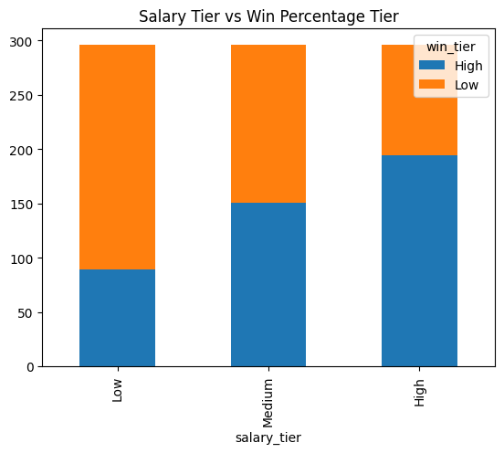

```python
cont_table.plot(kind='bar', stacked=True, title='Salary Tier vs Win Percentage Tier')
```

*Bar Chart Analysis*

Based on the graph, as we move by salary tier, the number of teams with a high W% increases and the number of teams with a low W% decreases.

**Primary Analysis**

It is expected that these features are equally important.

```python
# Setup and scaling
from sklearn.model_selection import train_test_split
from sklearn.preprocessing import StandardScaler

X = aggregate_teams[['avg_runs_scored', 'avg_runs_allowed']]
y = aggregate_teams['W%']
X_train, X_test, y_train, y_test = train_test_split(X, y, random_state=RANDOM_STATE)
scaler = StandardScaler()
X_train_scaled = scaler.fit_transform(X_train)
X_test_scaled = scaler.transform(X_test)
```

```python
# Running model
from sklearn.linear_model import LinearRegression

regr = LinearRegression()
regr.fit(X_train, y_train)
print(f'R^2 score on test data: {regr.score(X_test, y_test):.3f}')
print(f'Importance of runs scored: {abs(regr.coef_[0]):.3f}')
print(f'Importance of runs allowed: {abs(regr.coef_[1]):.3f}')
```

```
R^2 score on test data: 0.880
Importance of runs scored: 0.100
Importance of runs allowed: 0.102
```

Now, we study how teams can best improve their runs scored and runs allowed. As shown above, improving either is equally important. Team ownership has the most control over what they spend money on. Does salary impact runs scored or runs allowed more?

```python
# Setup and scaling
from sklearn.model_selection import train_test_split
from sklearn.preprocessing import StandardScaler
from sklearn.preprocessing import PolynomialFeatures

columns = ['avg_runs_scored','avg_runs_allowed']
X = aggregate_teams[['salary/avg_salary']]
y = aggregate_teams[columns]

X_train, X_test, y_train, y_test = train_test_split(X, y, random_state=RANDOM_STATE)
scaler = StandardScaler()
X_train_scaled = scaler.fit_transform(X_train)
X_test_scaled = scaler.transform(X_test)
poly = PolynomialFeatures(degree=2, include_bias=False)
X_train_poly = poly.fit_transform(X_train_scaled)
X_test_poly = poly.transform(X_test_scaled)
features = poly.get_feature_names_out(['standardized salary'])
X_train_poly = pd.DataFrame(X_train_poly, columns=features)
X_test_poly = pd.DataFrame(X_test_poly, columns=features)
```

```python
# Running model
from sklearn.linear_model import LinearRegression
from sklearn.metrics import r2_score

regr = LinearRegression()
regr.fit(X_train_poly, y_train)
y_pred = regr.predict(X_test_poly)
for i, name in enumerate(columns):
    pred = y_pred[:,i]
    actual = y_test[name]
    print(f'R^2 score on {name}: {r2_score(actual, pred):.3f}')

feature_importance_df = pd.DataFrame(regr.coef_).transpose()
feature_importance_df['feature'] = X_train_poly.columns

feature_importance_columns = [f'coef for {name}' for name in columns]
feature_importance_columns.append('feature')

feature_importance_df.columns = feature_importance_columns
print(feature_importance_df)
```

```
R^2 score on avg_runs_scored: 0.103
R^2 score on avg_runs_allowed: 0.050
   coef for avg_runs_scored  coef for avg_runs_allowed                feature
0                  0.105899                  -0.117460    standardized salary
1                  0.014313                   0.025883  standardized salary^2
```

Firstly, the R^2 scores show that salary has stronger effect on runs scored than runs allowed. Teams get more results from spending money on offense. We also see that the prediction for runs scored uses mostly the first power of standardized salary, while the prediction for runs allowed uses more of the second power of standardized salary. Runs allowed should be decreasing as salary increases, but the positive coefficient for the second power of salary on runs allowed shows that at the upper end of salary, the pitching does not improve much to allow fewer runs. This indicates that spending money on pitching has an effect initially, but not at the higher end salary levels. Pitching may be too inconsistent to give elite pitchers a lot of money.

We will create a plot that shows this relationship.

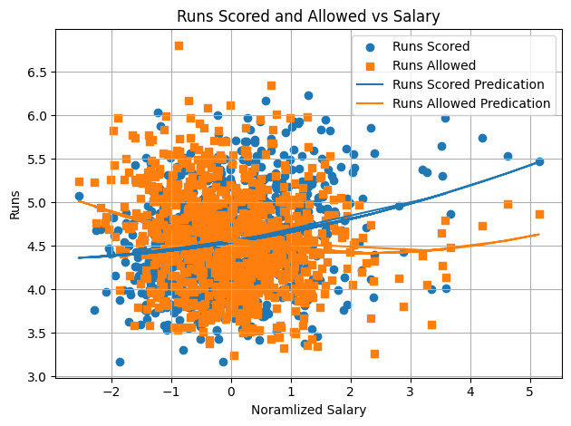

```python
scaler = StandardScaler()
normalized = scaler.fit_transform(aggregate_teams[['salary/avg_salary']])

runs_scored_c = regr.intercept_[0]
runs_scored_b = feature_importance_df['coef for avg_runs_scored'].tolist()[0]
runs_scored_a = feature_importance_df['coef for avg_runs_scored'].tolist()[1]
runs_scored_pred = runs_scored_a * normalized * normalized + runs_scored_b * normalized + runs_scored_c

runs_allowed_c = regr.intercept_[1]
runs_allowed_b = feature_importance_df['coef for avg_runs_allowed'].tolist()[0]
runs_allowed_a = feature_importance_df['coef for avg_runs_allowed'].tolist()[1]
runs_allowed_pred = runs_allowed_a * normalized * normalized + runs_allowed_b * normalized + runs_allowed_c

plt.scatter(normalized, aggregate_teams['avg_runs_scored'], label='Runs Scored', marker='o')
plt.scatter(normalized, aggregate_teams['avg_runs_allowed'], label='Runs Allowed', marker='s')
plt.plot(normalized, runs_scored_pred, label='Runs Scored Predication')
plt.plot(normalized, runs_allowed_pred, label='Runs Allowed Predication')

plt.xlabel('Noramlized Salary')
plt.ylabel('Runs')
plt.title('Runs Scored and Allowed vs Salary')
plt.legend()
plt.grid(True)
plt.tight_layout()
plt.show()
```

Money spent has been shown to have an impact on runs scored. What aspects should teams try to improve? We will use polynomials of the offensive stats, then run Random Forest to find feature importances.

```python
# Imports
from sklearn.model_selection import train_test_split
from sklearn.ensemble import RandomForestRegressor
from sklearn.preprocessing import PolynomialFeatures

from sklearn.feature_selection import SelectFromModel
from sklearn.metrics import mean_absolute_error, mean_squared_error, r2_score
```

```
Score using degree 1 polynomial: 0.887
Score using degree 2 polynomial: 0.893
Score using degree 3 polynomial: 0.891
Score using degree 4 polynomial: 0.890
```

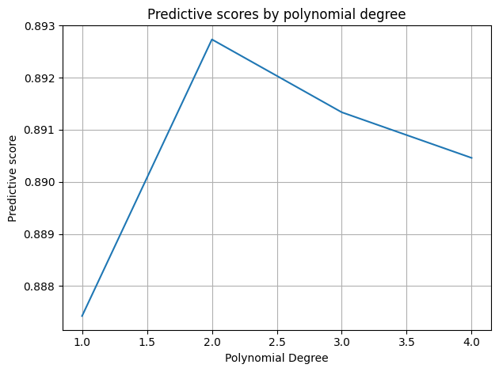

```python
# Only keeping the underlying stats in X to determine which are most important to win rate
columns = ['AVG', 'OBP', 'SLG']
X = aggregate_teams[columns]
y = aggregate_teams['avg_runs_scored']

degrees = []
scores = []
for i in range(1, 5):
    X_train, X_test, y_train, y_test = train_test_split(X, y, random_state=RANDOM_STATE)
    poly = PolynomialFeatures(degree=i)
    X_train_poly = poly.fit_transform(X_train)
    X_test_poly = poly.transform(X_test)
    features = poly.get_feature_names_out(columns)
    X_train_poly = pd.DataFrame(X_train_poly, columns=features)
    X_test_poly = pd.DataFrame(X_test_poly, columns=features)

    regr = RandomForestRegressor(random_state=RANDOM_STATE)
    regr.fit(X_train_poly, y_train)
    score = regr.score(X_test_poly, y_test)
    degrees.append(i)
    scores.append(score)
    print(f'Score using degree {i} polynomial: {score:.3f}')

plt.plot(degrees, scores)

plt.xlabel('Polynomial Degree')
plt.ylabel('Predictive score')
plt.title('Predictive scores by polynomial degree')
plt.grid(True)
plt.tight_layout()
plt.show()
```

Going beyond degree 2 polynomials does not improve predictive results, so we will use quadratics. With an R^2 score of 0.893, the quadratics of offensive stats (batting average, on base percentage, and slugging) predict 89.3% of the variance in runs scored for a team, so the predictions are effective.

```python
POLY_DEG=2
```

```python
# Running the quadratic model again
X_train, X_test, y_train, y_test = train_test_split(X, y, random_state=RANDOM_STATE)
poly = PolynomialFeatures(degree=POLY_DEG)
X_train_poly = poly.fit_transform(X_train)
X_test_poly = poly.transform(X_test)
features = poly.get_feature_names_out(columns)
X_train_poly = pd.DataFrame(X_train_poly, columns=features)
X_test_poly = pd.DataFrame(X_test_poly, columns=features)
regr = RandomForestRegressor(random_state=RANDOM_STATE)
regr.fit(X_train_poly, y_train)
```

```
RandomForestRegressor(random_state=42)
```

```python
feature_importance_df = pd.DataFrame(regr.feature_importances_)
feature_importance_df['feature'] = X_train_poly.columns
feature_importance_df.columns = ['importance', 'feature']
print(feature_importance_df)
```

```
   importance  feature
0    0.000000        1
1    0.006969      AVG
2    0.010811      OBP
3    0.006603      SLG
4    0.007745    AVG^2
5    0.012161  AVG OBP
6    0.016246  AVG SLG
7    0.011573    OBP^2
8    0.921186  OBP SLG
9    0.006705    SLG^2
```

By far, the most important feature in this Random Forest model is on base percentage (OBP) * slugging (SLG). The effectiveness of this Random Forest model indicates that OBP * SLG is a strong metric for predicting the nubmer of runs scored by a team. Generally, the metric OPS = OBP + SLG has been used as an overall measure of offensive success, but teams should consider using OBP * SLG instead.

```python
aggregate_teams['OBP SLG'] = aggregate_teams['OBP'] * aggregate_teams['SLG']
```

```python
feats=SelectFromModel(regr, threshold=0.89).fit(X_train_poly, y_train)
indcs=feats.get_support()
newX = X_train_poly.iloc[:,indcs]

new_regr = RandomForestRegressor(random_state=RANDOM_STATE)
new_regr.fit(newX, y_train)
newX_test = X_test_poly.iloc[:,indcs]
new_y_pred = new_regr.predict(newX_test)

mae = mean_absolute_error(y_test, new_y_pred)
mse = mean_squared_error(y_test, new_y_pred)
rmse = mse**0.5
r2 = r2_score(y_test, new_y_pred)

print(f"MAE: {mae:.4f}")
print(f"MSE: {mse:.4f}")
print(f"RMSE: {rmse:.4f}")
print(f"R2: {r2:.4f}")
```

```
MAE: 0.1540
MSE: 0.0368
RMSE: 0.1919
R2: 0.8562
```

along with the error statistics being low, R^2 is ~86% while using only OBP*SLG as the model's feature, which is only a very few percentages down from our older model's score that was using so many features

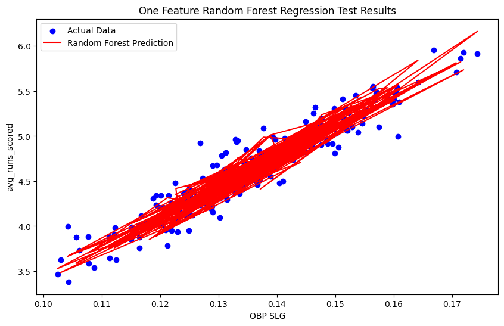

```python
plt.figure(figsize=(10, 6))
plt.scatter(newX_test, y_test, color='blue', label='Actual Data')
plt.plot(newX_test, new_y_pred, color='red', label='Random Forest Prediction')
plt.xlabel('OBP SLG')
plt.ylabel('avg_runs_scored')
plt.title('One Feature Random Forest Regression Test Results')
plt.legend()
plt.show()
```

clearly, the model is still able to figure out a relationship with just one feature and average runs scored; **it is very likely that small increases in OBP SLG can result in larger increases in average runs scored**

**Conclusion**

Linear regression showed that both runs allowed and runs scored matter equally to a team's win percentage or chance of winning the game. This shows that baseball teams should invest in both offense (batting) and defense (pitching/fielding).

Polynomial regression showed that an increase in salary has a larger effect on runs scored instead of runs allowed. Spending on offense is more valuable than spending on defense.

The random forest model showed that the best metric to predict runs scored by a team was on-base percentage (OBP) and slugging percentage (SLG). They are better predictors than traditional and more common stats like batting average. The random forest model had a $R^2$ of around 0.86 which suggests that the model is extremely effective.

Overall, baseball teams should value both offense and defense equally, but may find that spending on offense is more reliable and easier to improve with larger salaries. Furthermore, teams should evaluate players using the metrics OBP and SLG instead of other commonly used metrics as they are better indicative of how good a player is offensively.

more information below on the topics & strategies used above

baseball  
https://en.wikipedia.org/wiki/Baseball

hypothesis testing  
https://latrobe.libguides.com/maths/hypothesis-testing

correlation  
https://www.ncl.ac.uk/webtemplate/ask-assets/external/maths-resources/statistics/regression-and-correlation/types-of-correlation.html

linear regression  
https://www.ibm.com/think/topics/linear-regression

random forest regressor  
https://scikit-learn.org/stable/modules/generated/sklearn.ensemble.RandomForestRegressor.html

curse of dimensionality  
https://medium.com/vlgiitr/the-curse-of-dimensionality-15f950e519d2

github repository link  
https://github.com/Charipi/CMSC320_Final/tree/neelbranch